# Visualización de despegues de vuelos en Argentina

La [base de datos de movimientos aeroportuarios en Argentina](https://datos.gob.ar/dataset/transporte-aterrizajes-despegues-registrados-por-empresa-argentina-navegacion-aerea-eana) contiene información con despegues y aterrizajes en los aeropuertos nacionales.

A partir de esto, pensé en aplicar herramientas de ETL en Pandas para armar algunas visualizaiones usando Geopandas, Seaborn y Plotl.

En archivo .html fue exportado de Jupyter Notebook y editado, agregado las visualizaciones en formato png. En el [repositorio](https://github.com/Marouxet/datascience), se pueden descargar los archivos y los datasets.

## Datasets

- Los datasets se encuentran desmembrados por años, en formato csv, desde el 2014 en adelante.
- A partir de esa información, generé un dataset desde el 2014 hasta el 2020 (inclusive) del que parto para hacer este trabajo.
- A esto le sumé información geográfica sobre los aeropuertos para poder hacer gráficos en geopandas. Esta información la tome de [The Global Airport Database](https://www.partow.net/miscellaneous/airportdatabase/)

```python
import pandas as pd
import numpy as np
import geopandas as gpd
import seaborn as sns
import matplotlib.pyplot as plt
import plotly.graph_objects as go
import plotly.express as px
```

## ETL: Ordenando y Limpiando los Datasets

### Location

Ubicación de los aeropuertos. Elimino información no útil, elimino Nan, cambio nombres de columnas

```python
location = pd.read_csv("GlobalAirportDatabase.txt", sep=":")
```

```python
location.reset_index(inplace=True)
location.drop(["3","5","6","7","8","9","10","11","12","13"], axis = 1,inplace = True)
location.columns = ["ICAO","IATA","Aeropuerto","Pais","Lat","Long"]
location.dropna(inplace=True)
```

```python
location.head()
```

|  | ICAO | IATA | Aeropuerto | Pais | Lat | Long |
| --- | --- | --- | --- | --- | --- | --- |
| 0 | AYGA | GKA | GOROKA | PAPUA NEW GUINEA | -6.082 | 145.392 |
| 2 | AYMD | MAG | MADANG | PAPUA NEW GUINEA | -5.207 | 145.789 |
| 3 | AYMH | HGU | MOUNT HAGEN | PAPUA NEW GUINEA | -5.826 | 144.296 |
| 4 | AYNZ | LAE | NADZAB | PAPUA NEW GUINEA | -6.570 | 146.726 |
| 5 | AYPY | POM | PORT MORESBY JACKSONS INTERNATIONAL | PAPUA NEW GUINEA | -9.443 | 147.220 |

### Datos

Información de datos.gob.ar. Concateno los datasets y genero uno nuevo

```python
datos2014 = pd.read_csv("aterrizajes-y-despegues-registrados-por-eana-2014 .csv",sep=";")
datos2015 = pd.read_csv("aterrizajes-y-despegues-registrados-por-eana-2015.csv",sep=";")
datos2016 = pd.read_csv("aterrizajes-y-despegues-registrados-por-eana-2016.csv",sep=";")
datos2017 = pd.read_csv("aterrizajes-y-despegues-registrados-por-eana-2017.csv",sep=";")
datos2018 = pd.read_csv("aterrizajes-y-despegues-registrados-por-eana-2018.csv",sep=";")
datos2019 = pd.read_csv("aterrizajes-y-despegues-registrados-por-eana-2019.csv",sep=";")
datos2020 = pd.read_csv("aterrizajes-y-despegues-registrados-por-eana-2020.csv",sep=";")

datos = pd.concat([datos2014,datos2015,datos2016,datos2017,datos2018,datos2019,datos2020],axis = 0)
```

```python
datos.head()
```

|  | Fecha | Hora | Clase de Vuelo | Clasificaci�n Vuelo | Tipo de Movimiento | Origen OACI | Destino OACI | Aerolinea Nombre | Aeronave |
| --- | --- | --- | --- | --- | --- | --- | --- | --- | --- |
| 0 | 01/01/2014 | 1.0 | No Regular | Cabotaje | Aterrizaje | SAME | SACO | SOL L�neas A�reas | SAAB SF34 |
| 1 | 01/01/2014 | 1.0 | Regular | Internacional | Despegue | SABE | SBGR | Gol Transportes A�reo | BOEING B-737 |
| 2 | 01/01/2014 | 1.0 | Regular | Cabotaje | Aterrizaje | SASJ | SABE | Austral L�neas A�reas | EMBRAER E-190 |
| 3 | 01/01/2014 | 1.0 | Regular | Cabotaje | Aterrizaje | SABE | SACO | Austral L�neas A�reas | EMBRAER E-190 |
| 4 | 01/01/2014 | 1.0 | Regular | Internacional | Despegue | SAEZ | KIAH | United Airlines | BOEING B-767 |

## Merging

En cada registro de datos, agrego información geográfica de ambos aeropuertos (despegue y aterrizaje). Para eso duplico la tabla location, generando una para despegues y otra para aterrizajes

```python
origen = location
origen.columns=["Origen OACI", "Origen IATA", "Airport Origen", "Country Origen", "Lat Origen", "Long Origen"]
```

```python
origen.head()
```

|  | Origen OACI | Origen IATA | Airport Origen | Country Origen | Lat Origen | Long Origen |
| --- | --- | --- | --- | --- | --- | --- |
| 0 | AYGA | GKA | GOROKA | PAPUA NEW GUINEA | -6.082 | 145.392 |
| 2 | AYMD | MAG | MADANG | PAPUA NEW GUINEA | -5.207 | 145.789 |
| 3 | AYMH | HGU | MOUNT HAGEN | PAPUA NEW GUINEA | -5.826 | 144.296 |
| 4 | AYNZ | LAE | NADZAB | PAPUA NEW GUINEA | -6.570 | 146.726 |
| 5 | AYPY | POM | PORT MORESBY JACKSONS INTERNATIONAL | PAPUA NEW GUINEA | -9.443 | 147.220 |

```python
union = pd.merge(datos, origen,left_on="Origen OACI", right_on = "Origen OACI", how = "outer")
```

```python
destino = location
destino.columns = ["Destino OACI", "Destino IATA", "Airport Destino", "Country Destino", "Lat Destino", "Long Destino"]
```

```python
union2 = pd.merge(union, destino,left_on="Destino OACI", right_on = "Destino OACI")
union2.head()
```

|  | Fecha | Hora | Clase de Vuelo | Clasificaci�n Vuelo | Tipo de Movimiento | Origen OACI | Destino OACI | Aerolinea Nombre | Aeronave | Origen IATA | Airport Origen | Country Origen | Lat Origen | Long Origen | Destino IATA | Airport Destino | Country Destino | Lat Destino | Long Destino |
| --- | --- | --- | --- | --- | --- | --- | --- | --- | --- | --- | --- | --- | --- | --- | --- | --- | --- | --- | --- |
| 0 | 10/01/2019 | 7.0 | Regular | Cabotaje | Aterrizaje | SAME | SABE | LATAM Argentina | AIRBUS A-320 | MDZ | EL PLUMERILLO | ARGENTINA | -32.832 | -68.793 | AEP | AEROPARQUE JORGE NEWBERY | ARGENTINA | -34.559 | -58.416 |
| 1 | 10/01/2019 | 7.0 | Regular | Cabotaje | Despegue | SAME | SABE | Norwegian Air Argenti | BOEING B-737 | MDZ | EL PLUMERILLO | ARGENTINA | -32.832 | -68.793 | AEP | AEROPARQUE JORGE NEWBERY | ARGENTINA | -34.559 | -58.416 |
| 2 | 10/01/2019 | 15.0 | Regular | Cabotaje | Aterrizaje | SAME | SABE | Norwegian Air Argenti | BOEING B-737 | MDZ | EL PLUMERILLO | ARGENTINA | -32.832 | -68.793 | AEP | AEROPARQUE JORGE NEWBERY | ARGENTINA | -34.559 | -58.416 |
| 3 | 10/01/2019 | 9.0 | Regular | Cabotaje | Despegue | SAME | SABE | Aerol�neas Argentinas | BOEING B-737 | MDZ | EL PLUMERILLO | ARGENTINA | -32.832 | -68.793 | AEP | AEROPARQUE JORGE NEWBERY | ARGENTINA | -34.559 | -58.416 |
| 4 | 10/01/2019 | 19.0 | Regular | Cabotaje | Despegue | SAME | SABE | Norwegian Air Argenti | BOEING B-737 | MDZ | EL PLUMERILLO | ARGENTINA | -32.832 | -68.793 | AEP | AEROPARQUE JORGE NEWBERY | ARGENTINA | -34.559 | -58.416 |

```python
union2.drop(["Hora", "Clase de Vuelo", "Clasificaci�n Vuelo", "Origen OACI", "Destino OACI"], axis = 1, inplace = True)
```

- Dado que el DataSet original listaba los *movimientos* aeroportuarios, cada ruta está duplicada, indicando cuando un avión despega de un aeropuerto nacional y cuando aterriza. Por eso, conservaremos únicamente los aterrizajes.

```python
datosOK = union2[union2["Tipo de Movimiento"]=="Aterrizaje"]
print("Dataset Size: ", datosOK.shape)
```

```
Dataset Size:  (178107, 14)
```

- Los Datos ya están organizados, y pasaremos a hacer algunas visualizaciones

```python
datosOK.head()
```

|  | Fecha | Tipo de Movimiento | Aerolinea Nombre | Aeronave | Origen IATA | Airport Origen | Country Origen | Lat Origen | Long Origen | Destino IATA | Airport Destino | Country Destino | Lat Destino | Long Destino |
| --- | --- | --- | --- | --- | --- | --- | --- | --- | --- | --- | --- | --- | --- | --- |
| 0 | 10/01/2019 | Aterrizaje | LATAM Argentina | AIRBUS A-320 | MDZ | EL PLUMERILLO | ARGENTINA | -32.832 | -68.793 | AEP | AEROPARQUE JORGE NEWBERY | ARGENTINA | -34.559 | -58.416 |
| 2 | 10/01/2019 | Aterrizaje | Norwegian Air Argenti | BOEING B-737 | MDZ | EL PLUMERILLO | ARGENTINA | -32.832 | -68.793 | AEP | AEROPARQUE JORGE NEWBERY | ARGENTINA | -34.559 | -58.416 |
| 6 | 10/01/2019 | Aterrizaje | Norwegian Air Argenti | BOEING B-737 | MDZ | EL PLUMERILLO | ARGENTINA | -32.832 | -68.793 | AEP | AEROPARQUE JORGE NEWBERY | ARGENTINA | -34.559 | -58.416 |
| 9 | 10/01/2019 | Aterrizaje | Norwegian Air Argenti | BOEING B-737 | MDZ | EL PLUMERILLO | ARGENTINA | -32.832 | -68.793 | AEP | AEROPARQUE JORGE NEWBERY | ARGENTINA | -34.559 | -58.416 |
| 11 | 10/01/2019 | Aterrizaje | Aerol�neas Argentinas | BOEING B-737 | MDZ | EL PLUMERILLO | ARGENTINA | -32.832 | -68.793 | AEP | AEROPARQUE JORGE NEWBERY | ARGENTINA | -34.559 | -58.416 |

### Visualización de rutas aréas

```python
locales = datosOK[datosOK["Country Origen"]=="ARGENTINA"]
localesGroup = locales.groupby(["Lat Origen","Long Origen","Lat Destino","Long Destino"]).count()[["Fecha"]].reset_index()
localesGroup.columns = ["Lat Origen","Long Origen","Lat Destino","Long Destino","Vuelos"]

internacionales = datosOK[datosOK["Country Origen"]!="ARGENTINA"]
internacionalesGroup=internacionales.groupby(["Lat Origen","Long Origen","Lat Destino","Long Destino"]).count()[["Fecha"]].reset_index()
internacionalesGroup.columns = ["Lat Origen","Long Origen","Lat Destino","Long Destino","Vuelos"]
```

## Rutas Internacionales

```python
fig = go.Figure()

origen_a_dest = zip(internacionalesGroup["Lat Origen"], internacionalesGroup["Long Origen"],
                     internacionalesGroup["Lat Destino"], internacionalesGroup["Long Destino"],
                     internacionalesGroup["Vuelos"])


##
for olat,olon, dlat, dlon, vuelos in origen_a_dest:
    fig.add_trace(go.Scattergeo(
                        lat = [olat,dlat],
                        lon = [olon, dlon],
                        mode = 'lines',
                        line = dict(width = 0.05*np.log(vuelos), color="red")
                        ))

##
fig.update_layout(
                  height=600, width=800, margin={"t":50,"b":0,"l":0, "r":0, "pad":0},
                  showlegend=False,
                  title={
                        'text': "Vuelos con origen en aeropuertos argentinos y destinos internacionales",
                        'y':0.97,
                        'x':0.5,
                        'xanchor': 'center',
                        'yanchor': 'top'},
                  geo = dict(projection_type = 'orthographic', showland = True),
                )
fig.show()
```

[figure not shown]

## Rutas Locales

```python
fig = go.Figure()

origen_a_dest = zip(localesGroup["Lat Origen"], localesGroup["Long Origen"],
                     localesGroup["Lat Destino"], localesGroup["Long Destino"],
                     localesGroup["Vuelos"])


##
for olat,olon, dlat, dlon, vuelos in origen_a_dest:
    fig.add_trace(go.Scattergeo(
                        lat = [olat,dlat],
                        lon = [olon, dlon],
                        mode = 'lines',
                        line = dict(width = 0.05*np.log(vuelos), color="red")
                        ))

##
fig.update_layout(
                  height=600, width=800, margin={"t":0,"b":0,"l":0, "r":0, "pad":0},
                  showlegend=False,
                  title={
                        'text': "Vuelos con origen en aeropuertos argentinos y destinos nacionales",
                        'y':0.97,
                        'x':0.5,
                        'xanchor': 'center',
                        'yanchor': 'top'},
                  geo = dict(projection_type = 'mercator',scope = 'south america'),
                )
fig.show()
```

[figure not shown]

## Vuelos locales: Destinos más frecuentes

Dado que la mayoría de las rutas locales son entre Aeroparque y otros aeropuertos, podemos visualizar en un gráfico tipo *treemap* esta división

```python
destinosAEP=locales[locales["Origen IATA"]=="AEP"].groupby("Destino IATA").count()[['Fecha']]
destinosAEP["ORIGEN"] = "AEP"
destinosAEP.reset_index(inplace=True)
destinosAEP.columns= ["Destino", "Cantidad", "Origen"]

fig = px.treemap(destinosAEP, path=['Origen', 'Destino'], values='Cantidad',
                  color_continuous_midpoint=np.average(destinosAEP['Cantidad'], weights=destinosAEP['Cantidad']))

fig.update_layout(
                  height=600, width=800, margin={"t":40,"b":0,"l":0, "r":0, "pad":0},

                  title={
                        'text': "Destinos nacionales con origen en Aeroparque",
                        'y':0.97,
                        'x':0.5,
                        'xanchor': 'center',
                        'yanchor': 'top'},
                )
fig.show()
```

[figure not shown]

## Aeronaves más frecuentes

Por último, podemos ver qué aeronave se utiliza más en todos los vuelos desde argentina

```python
aeronaves=datosOK.groupby("Aeronave").count()[["Fecha"]]
aeronaves.reset_index(inplace=True)
aeronaves.columns = ["Aeronave", "Cantidad de Vuelos"]
aeronaves.head()
```

|  | Aeronave | Cantidad de Vuelos |
| --- | --- | --- |
| 0 | AERO AC50 | 13 |
| 1 | AERO AC68 | 3 |
| 2 | AERO BOERO AB11 | 89 |
| 3 | AERO BOERO AB18 | 34 |
| 4 | AERO COMMANDER | 17 |

Graficaremos únicamente aquellas aviones que aparecen más de 500 veces, dado que hay muchos aviones muy pequeños con muy pocos viajes en todos los años estudiados

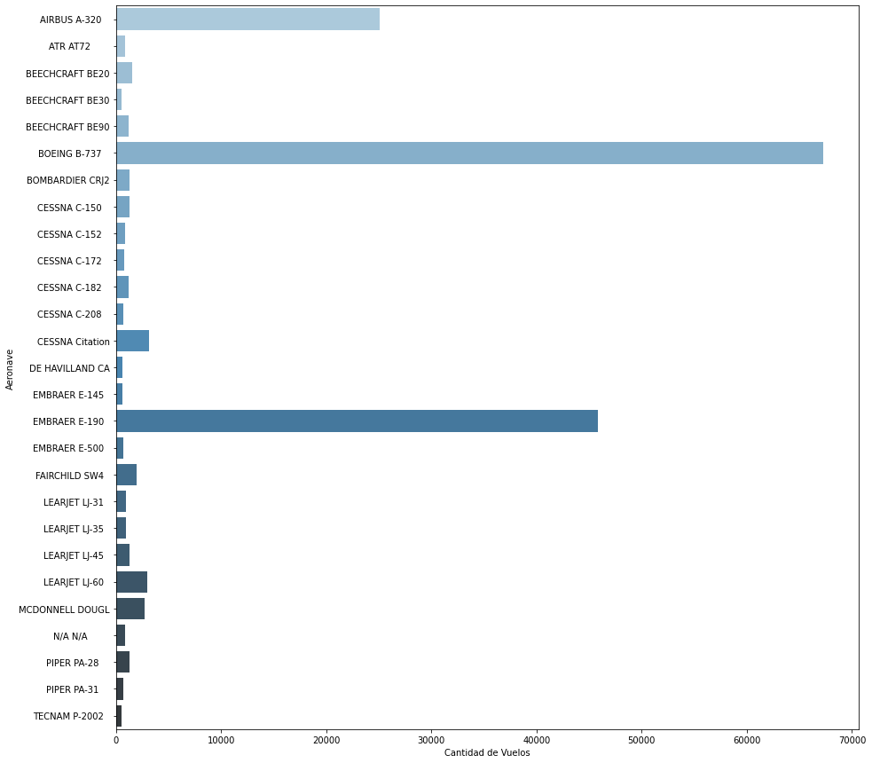

```python
plt.figure(figsize=(15, 15))
sns.barplot(y="Aeronave",x="Cantidad de Vuelos",
                  data = aeronaves[aeronaves["Cantidad de Vuelos"]>500],palette="Blues_d")
```